# 2012 Data RMD V3

Scott Stoner

2023

## Data Import

This section covers importing lake chemistry and watershed data for the purpose of lake selection. The relevant data is first retrieved from one of the NLS 2012 csv files. These variables fall into three categories, watershed information, water chemistry data, and diatom phytoplankton counts. Additional variables are included to help with ID or shed light on connections made during anlaysis. Variable names and notes are included for each imported data set.

#### Site Info

- AREA_HA (lake area, hectares)
- STATE
- SIZE_CLASS
- SITETYPE (probability or handpicked)
- ELEVATION
- FS_EW (forest service land east or west)
- DSGN12 (incorporated in the NLA2012 design framework)
- NA_L2CODE (ecoregion level 2)
- NA_L3CODE (ecoregion level 3)
- URBAN (determination based on land use)
- EVAL_NAME (lake name)
- LAKE_ORIGIN (“manmade or natural”)
- PERIM_KM (lake perimeter)
- SITESAMP (was site sampled)
- DATE_COL (date of sample collection)
- SITE_ID (id code for site 2012 version)
- VISIT_NO (visit number for site)
- UID (unique site visit id)

```r
tb_import(c("UID",
            "SITE_ID",
            "VISIT_NO",
            "DATE_COL",
            "SITETYPE",
            "SITESAMP",
            "DSGN12",
            "EVAL_NAME",
            "STATE",
            "ELEVATION",
            "AREA_HA",
            "PERIM_KM",
            "SIZE_CLASS",
            "FS_EW",
            "NA_L2CODE",
            "NA_L3CODE",
            "URBAN",
            "LAKE_ORIGIN"),
          "./data/nla2012_wide_siteinfo_08232016.csv") -> siteinfo
```

#### Watershed Data

- SITE_ID
- DOMGEOL_BSN (dominant geology)
- NLCD2006_ASSIGNEDAREA_BSN (area within basin assigned nlcd value*)
- NLCD2006_DEVELOPEDPCT_BSN (percent developed)
- NLCD2006_FORESTPCT_BSN (percent forest)
- NLCD2006_IMPERVAREA_BSN (percent impervious)
- PMEAN_BSN (mean annual precipitation in basin)[multiple precip values]
- TMEANPY_BSN (mean temperature in basin 12 months)[multiple temp values]

```r
tb_import(c("SITE_ID", "DOMGEOL_BSN", "NLCD2006_ASSIGNEDAREA_BSN", "NLCD2006_DEVELOPEDPCT_BSN", "NLCD2006_FORESTPCT_BSN", "NLCD2006_IMPERVAREA_BSN", "PMEAN_BSN", "TMEANPY_BSN"), "./data/nla2012_wide_watershed.csv") -> watershed
```

#### Water Chemistry Data

- UID
- NTL_RESULT (Total Nitrogen mg/L)
- PTL_RESULT (Total Phosphorus ug/L)
- PH_RESULT
- TURB_RESULT

```r
tb_import(c("UID", "NTL_RESULT", "PTL_RESULT", "PH_RESULT", "TURB_RESULT"), "./data/nla2012_waterchem_wide.csv") -> waterchem
```

#### Phytoplankton Data

- UID
- SAMPLE_ID
- VISIT_NO
- ABUNDANCE
- ALGAL_GROUP
- TAXA_ID

```r
tb_import(c("UID", "SAMPLE_ID", "VISIT_NO", "ABUNDANCE", "ALGAL_GROUP", "TAXA_ID"), "./data/nla2012_wide_phytoplankton_count_02122014.csv") %>%
  dplyr::filter(ALGAL_GROUP == "DIATOM") %>%
  dplyr::filter(VISIT_NO == 1) -> phyto_count
```

## Lake Selection

#### Data Merge and Initial Filter

The selected watershed and water chemistry data from the imported tables is now combined into a single table that will be used for lake selection. A left join using the SITE_ID field to append watershed data to general site info. Then a left join is used to append the water chemistry data to each visit using the UID field. This table is then filtered to remove undesired lakes. First, lakes with no sampling data are excluded, followed by lakes that were not randomly selected, and third by visit number, removing duplicate visits.

#### Lake Selection

In the same code chunk below is where the bulk of the lake selection process happens.

List of selection conditions in order:

1. NA_L2CODE = 6.2
- The 6.2 NA Ecoregion 2 Code represents the “Western Cordillera” also known as the Northwestern Forested Mountain Region.
2. STATE = CA, OR, WA, ID, MT
- The restriction to these 5 states removes areas of Ecoregion 6.2 that are mostly in Colorado and New Mexico.
3. Possible to use more criteria here to narrow selection.

```r
siteinfo %>%
  dplyr::left_join(watershed, by = "SITE_ID") %>%
  dplyr::left_join(waterchem, by = "UID") %>%
  dplyr::filter(SITESAMP == "Y") %>%
  dplyr::filter(SITETYPE == "PROB") %>%
  dplyr::filter(VISIT_NO == 1) %>%
  dplyr::filter(NA_L2CODE == 6.2) %>%
  dplyr::filter(STATE == "CA" | STATE == "OR" | STATE == "WA" | STATE == "ID" | STATE == "MT") -> watershed_filter_result
```

#### Phytoplankton Data Selection

The lake selection criteria is applied to the phytoplankton count data using the UID field while also appending phosphorus data. Then two data frames are created; one with rows for each UID and columns for each TAXA_ID (values based on ABUNDANCE), and another that lists the max abundance for each taxa and the corresponding phosphorus values for that abundance value. The first data frame, phyto_rf is set up to conduct both a PCA and Random Forest approach to compare results later on.

```r
watershed_filter_result %>%
  dplyr::select("UID", "PTL_RESULT") -> watershed_filter_IDs

phyto_count %>%
  dplyr::inner_join(watershed_filter_IDs, by = "UID",suffix = c(".x", ".y")) -> phyto_filtered

phyto_filtered %>%
  dplyr::select("PTL_RESULT", "TAXA_ID", "ABUNDANCE") %>%
  dplyr::group_by(TAXA_ID) %>%
  pivot_wider(names_from = TAXA_ID, values_from = ABUNDANCE, values_fn = sum, names_glue = "TID_{TAXA_ID}") %>%
  log() %>%
  replace(is.na(.), 0) -> phyto_rf

phyto_filtered %>%
  select(TAXA_ID, PTL_RESULT, ABUNDANCE) %>%
  group_by(TAXA_ID) %>%
  arrange(TAXA_ID, desc(ABUNDANCE)) %>%
  filter(row_number() == 1) -> phyto_max_abundance
```

## Data Summary

These are summary statistics for the watershed and water chemistry variables of interest.

```r
watershed_filter_result %>%
  select("UID", "NLCD2006_ASSIGNEDAREA_BSN", "NLCD2006_DEVELOPEDPCT_BSN", "NLCD2006_FORESTPCT_BSN", "NLCD2006_IMPERVAREA_BSN", "PMEAN_BSN", "TMEANPY_BSN", "NTL_RESULT", "PTL_RESULT", "PH_RESULT", "TURB_RESULT") %>%
  summary() %>%
  knitr::kable(format='simple', align='c', padding = 3, label = 'WATERSHED', digits = round(3))
```

|  | UID | NLCD2006_ASSIGNEDAREA_BSN | NLCD2006_DEVELOPEDPCT_BSN | NLCD2006_FORESTPCT_BSN | NLCD2006_IMPERVAREA_BSN | PMEAN_BSN | TMEANPY_BSN | NTL_RESULT | PTL_RESULT | PH_RESULT | TURB_RESULT |
| --- | --- | --- | --- | --- | --- | --- | --- | --- | --- | --- | --- |
|  | Min. : 6559 | Min. : 0.070 | Min. : 0.0000 | Min. : 0.9744 | Min. : 0.00000 | Min. : 34253 | Min. : -50.37 | Min. :0.01400 | Min. : 4.00 | Min. :6.020 | Min. :0.010 |
|  | 1st Qu.: 7259 | 1st Qu.: 1.653 | 1st Qu.: 0.0000 | 1st Qu.:45.2671 | 1st Qu.: 0.00010 | 1st Qu.: 86633 | 1st Qu.: 391.80 | 1st Qu.:0.09525 | 1st Qu.: 10.62 | 1st Qu.:7.145 | 1st Qu.:0.320 |
|  | Median : 7937 | Median : 7.803 | Median : 0.0000 | Median :65.8548 | Median : 0.01047 | Median :116180 | Median : 572.91 | Median :0.16800 | Median : 25.50 | Median :7.535 | Median :0.625 |
|  | Mean : 152965 | Mean : 253.116 | Mean : 1.5864 | Mean :60.5675 | Mean : 2.04556 | Mean :127350 | Mean : 580.58 | Mean :0.30065 | Mean : 38.10 | Mean :7.573 | Mean :1.128 |
|  | 3rd Qu.: 8478 | 3rd Qu.: 52.056 | 3rd Qu.: 0.8739 | 3rd Qu.:80.0400 | 3rd Qu.: 0.11035 | 3rd Qu.:156946 | 3rd Qu.: 724.75 | 3rd Qu.:0.32725 | 3rd Qu.: 47.75 | 3rd Qu.:7.938 | 3rd Qu.:1.315 |
|  | Max. :1000194 | Max. :15523.061 | Max. :58.3435 | Max. :96.6945 | Max. :99.43784 | Max. :324096 | Max. :1205.23 | Max. :2.61000 | Max. :288.00 | Max. :9.360 | Max. :7.780 |
|  | NA | NA | NA | NA | NA | NA | NA | NA | NA | NA | NA’s :16 |

Here are two plots of phosphorus showing the relatively even distribution after log transformation. Phosphorus has been log transformed for all calculations.

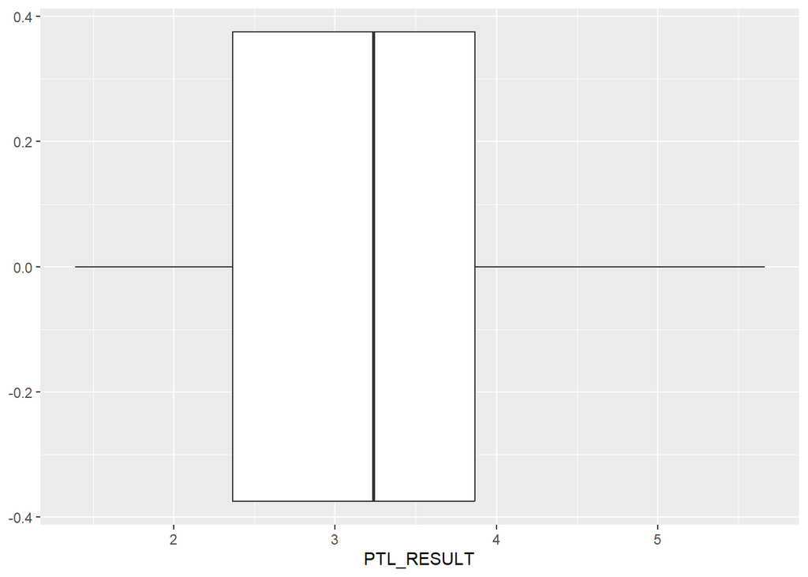

```r
watershed_filter_result %>%
  dplyr::select(PTL_RESULT) %>%
  log %>%
  tb_boxplot_single(PTL_RESULT)
```

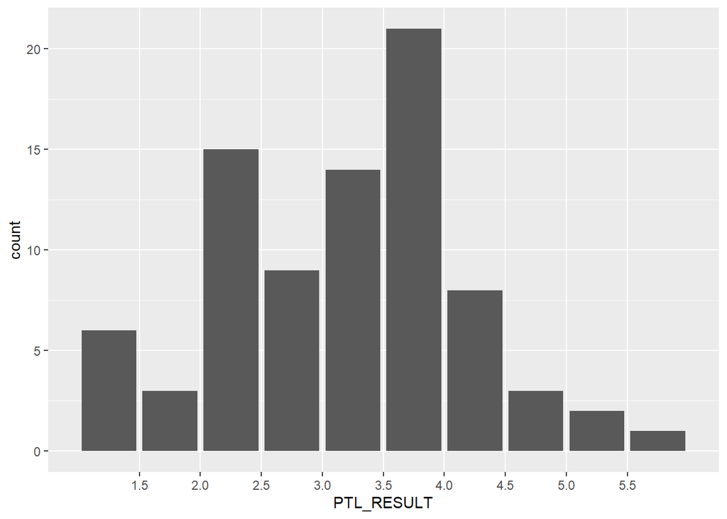

```r
watershed_filter_result %>%
  dplyr::select(PTL_RESULT) %>%
  log %>%
  tb_histogram(PTL_RESULT)
```

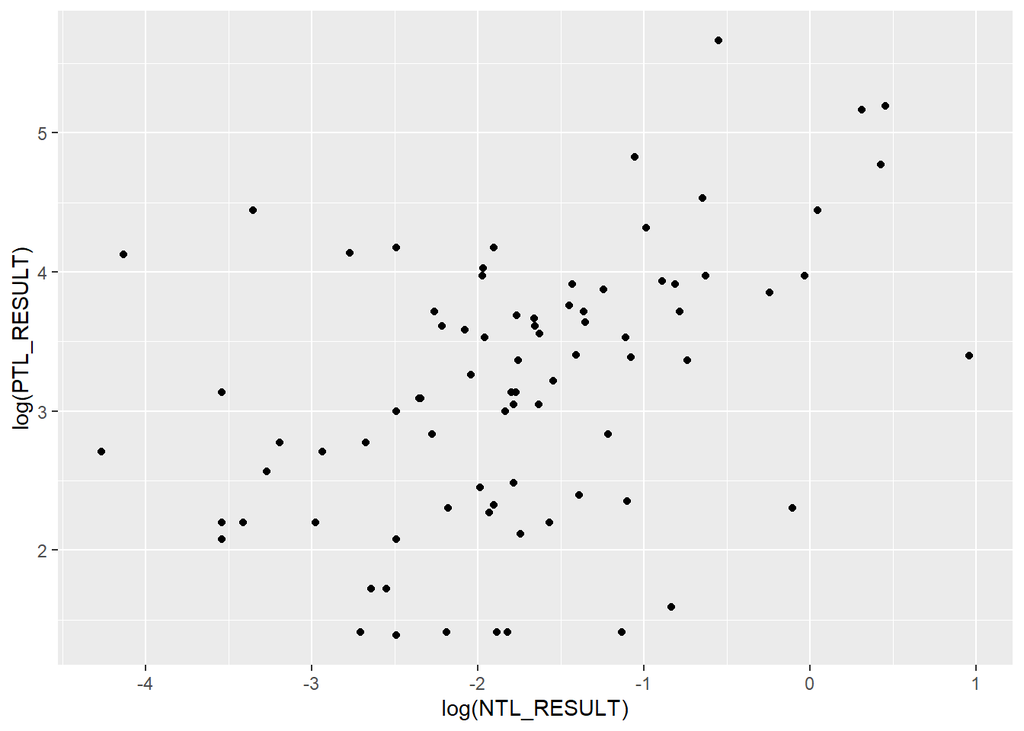

```r
ggplot(watershed_filter_result, aes(x = log(NTL_RESULT), y = log(PTL_RESULT))) +
  geom_point()
```

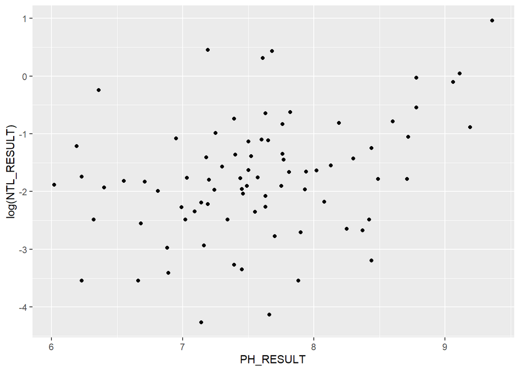

```r
ggplot(watershed_filter_result, aes(x = PH_RESULT, y = log(NTL_RESULT))) +
  geom_point()
```

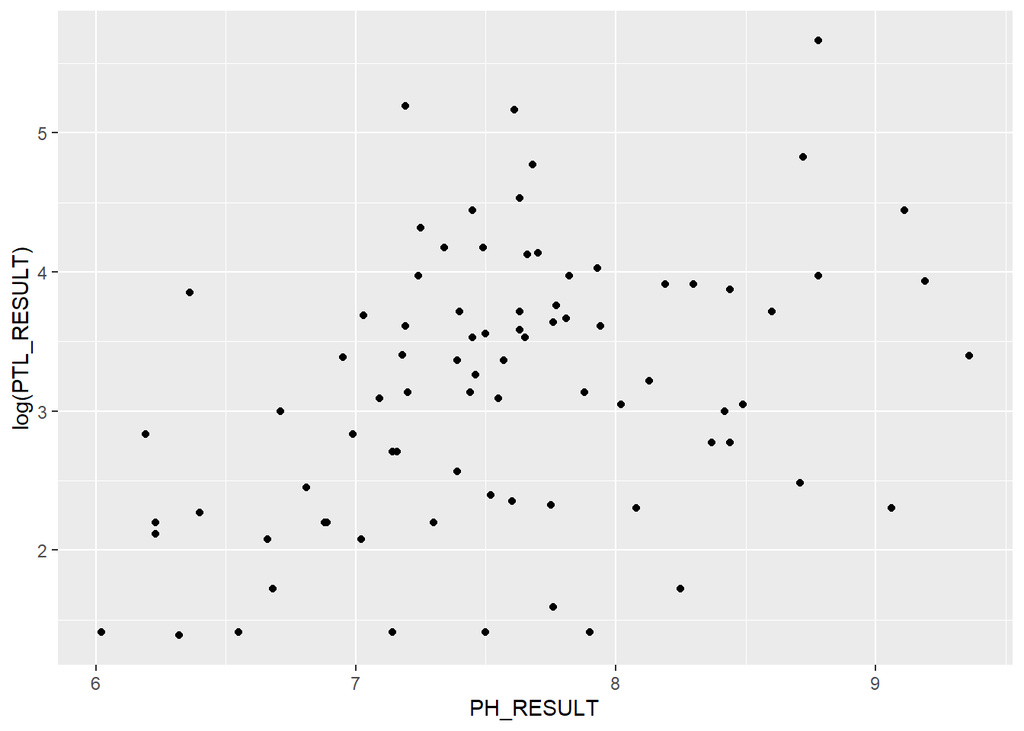

```r
ggplot(watershed_filter_result, aes(x = PH_RESULT, y = log(PTL_RESULT))) +
  geom_point()
```

## PCA

First the SVD is calculated with prcomp() and a summary is produced for each principle component.

```r
phyto_rf[,-c(1)] %>%
  prcomp() -> phyto_pca

print(summary(phyto_pca))
```

```
## Importance of components:
##                           PC1    PC2    PC3     PC4     PC5     PC6    PC7
## Standard deviation     2.6844 2.3537 2.0779 1.78534 1.64596 1.39403 1.3242
## Proportion of Variance 0.1948 0.1497 0.1167 0.08616 0.07324 0.05253 0.0474
## Cumulative Proportion  0.1948 0.3446 0.4613 0.54743 0.62066 0.67320 0.7206
##                            PC8     PC9    PC10    PC11    PC12    PC13    PC14
## Standard deviation     1.19075 1.14772 1.08961 0.98840 0.91262 0.83490 0.81478
## Proportion of Variance 0.03833 0.03561 0.03209 0.02641 0.02251 0.01884 0.01795
## Cumulative Proportion  0.75893 0.79454 0.82663 0.85304 0.87555 0.89440 0.91234
##                           PC15    PC16    PC17    PC18    PC19    PC20    PC21
## Standard deviation     0.74304 0.65470 0.59215 0.57606 0.51725 0.44880 0.40717
## Proportion of Variance 0.01492 0.01159 0.00948 0.00897 0.00723 0.00544 0.00448
## Cumulative Proportion  0.92727 0.93885 0.94833 0.95730 0.96453 0.96998 0.97446
##                          PC22    PC23    PC24    PC25    PC26    PC27    PC28
## Standard deviation     0.3893 0.37150 0.33511 0.32076 0.28458 0.26674 0.25019
## Proportion of Variance 0.0041 0.00373 0.00304 0.00278 0.00219 0.00192 0.00169
## Cumulative Proportion  0.9786 0.98229 0.98532 0.98810 0.99029 0.99222 0.99391
##                           PC29   PC30    PC31   PC32    PC33    PC34    PC35
## Standard deviation     0.23805 0.1928 0.18811 0.1822 0.13528 0.11380 0.09862
## Proportion of Variance 0.00153 0.0010 0.00096 0.0009 0.00049 0.00035 0.00026
## Cumulative Proportion  0.99544 0.9964 0.99740 0.9983 0.99879 0.99914 0.99941
##                           PC36    PC37    PC38    PC39    PC40    PC41
## Standard deviation     0.09272 0.07666 0.06027 0.05008 0.03112 0.01870
## Proportion of Variance 0.00023 0.00016 0.00010 0.00007 0.00003 0.00001
## Cumulative Proportion  0.99964 0.99980 0.99990 0.99996 0.99999 1.00000
##                             PC42      PC43      PC44      PC45      PC46
## Standard deviation     1.989e-16 1.886e-16 1.886e-16 1.886e-16 1.886e-16
## Proportion of Variance 0.000e+00 0.000e+00 0.000e+00 0.000e+00 0.000e+00
## Cumulative Proportion  1.000e+00 1.000e+00 1.000e+00 1.000e+00 1.000e+00
##                             PC47      PC48      PC49      PC50      PC51
## Standard deviation     1.886e-16 1.886e-16 1.886e-16 1.886e-16 1.886e-16
## Proportion of Variance 0.000e+00 0.000e+00 0.000e+00 0.000e+00 0.000e+00
## Cumulative Proportion  1.000e+00 1.000e+00 1.000e+00 1.000e+00 1.000e+00
##                             PC52
## Standard deviation     1.886e-16
## Proportion of Variance 0.000e+00
## Cumulative Proportion  1.000e+00
```

Then a scatter plot of PC 1 and PC 2 are created, the points colored based on phosphorus value. In this case there appears to be a slight separation in different directions based on phosphorus (V shape), with higher phosphorus related to higher PC 2 values.

#### PC1 and PC2

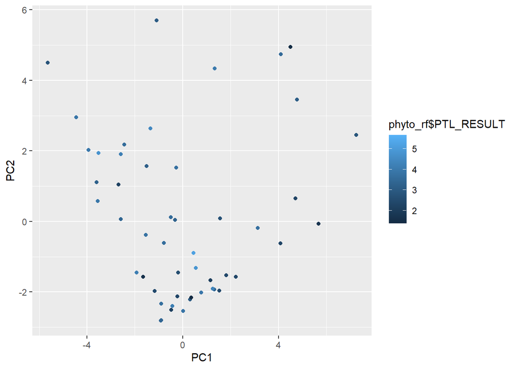

```r
phyto_pca$x %>%
  data.frame() %>%
  ggplot(aes(x = PC1, y = PC2, color = phyto_rf$PTL_RESULT)) +
  geom_point()
```

#### PCA Biplot

To investigate this further, a biplot is created. From this it’s possible to see that diatoms with Taxa_IDs 4075, 4849, and 4182 are potentially indicators of higher phosphorus levels.

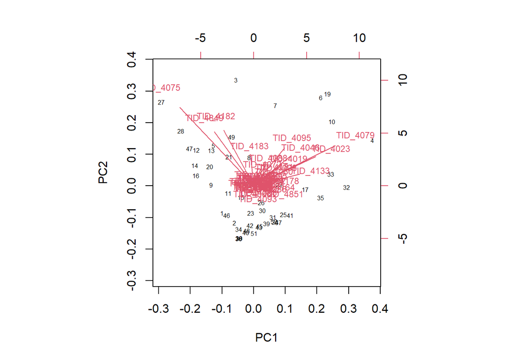

```r
biplot(phyto_pca, arrow.len=0, cex = c(0.5,0.75))
```

#### PCA Results Analysis

What follows are a few plots of these selected diatom taxa that show a potential skew in the direction of higher phosphorus compared to the average distribution of phosphorus.

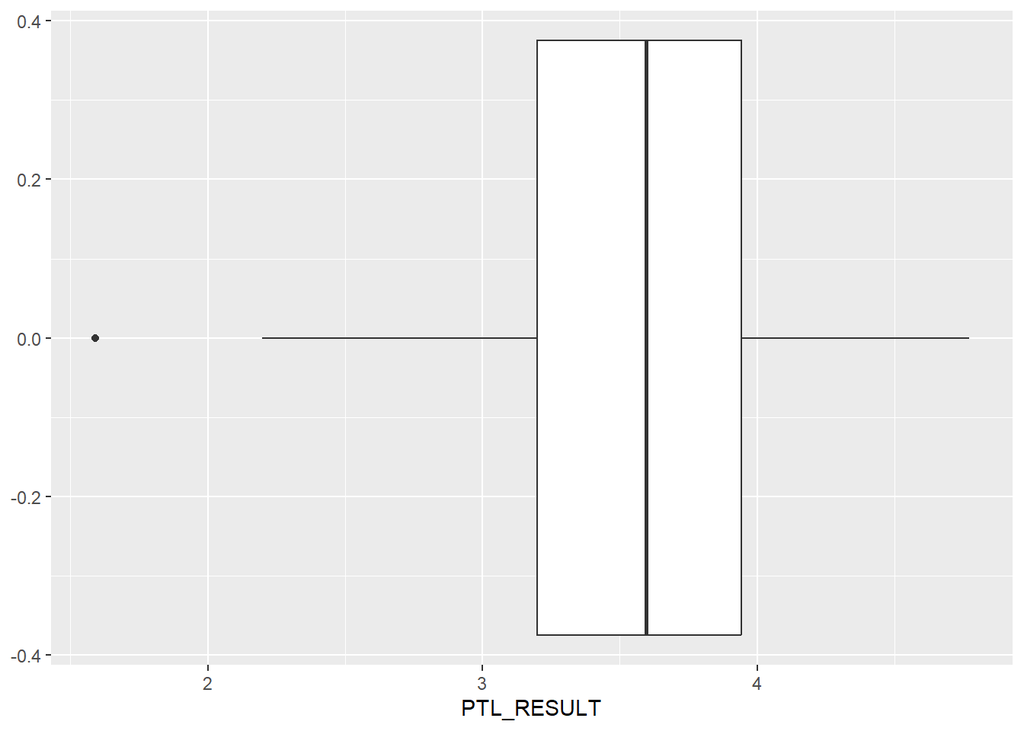

```r
phyto_rf %>%
  select(PTL_RESULT, TID_4075) %>%
  filter(TID_4075 > 0) %>%
  ggplot(aes(PTL_RESULT)) +
    geom_boxplot()
```

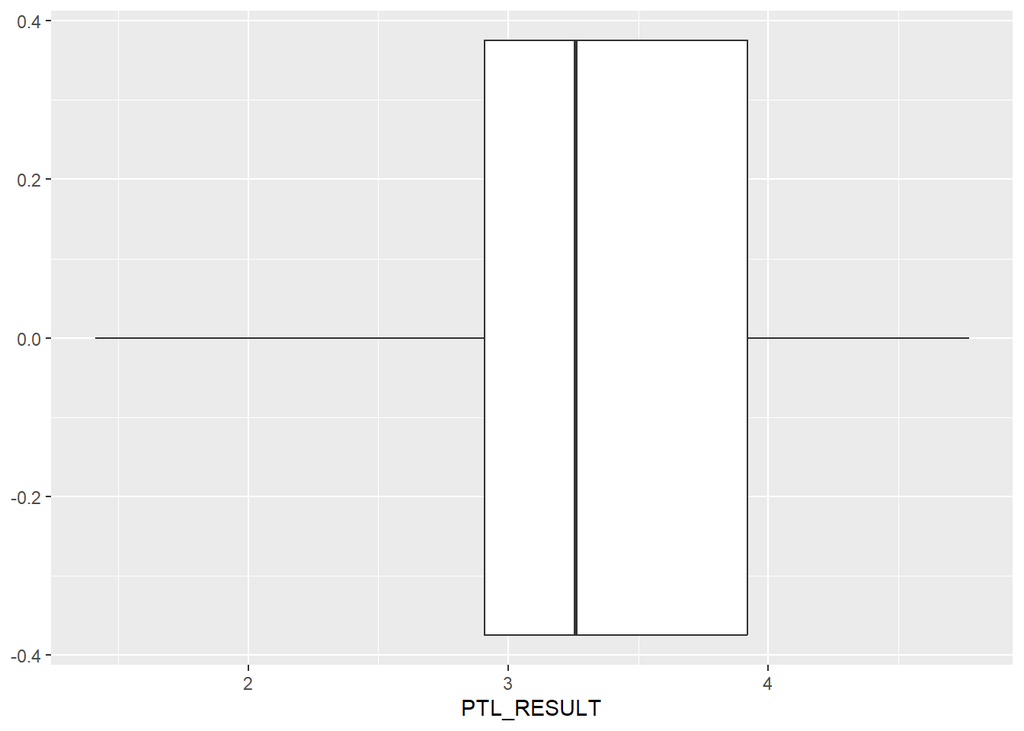

```r
phyto_rf %>%
  select(PTL_RESULT, TID_4849) %>%
  filter(TID_4849 > 0) %>%
  ggplot(aes(PTL_RESULT)) +
    geom_boxplot()
```

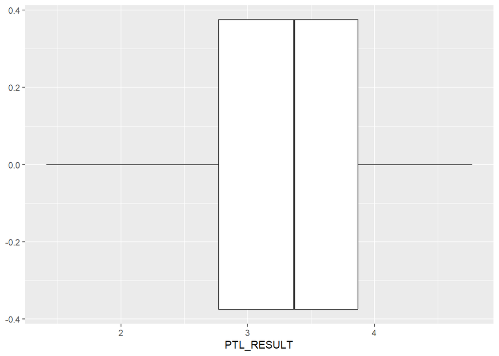

```r
phyto_rf %>%
  select(PTL_RESULT, TID_4182) %>%
  filter(TID_4182 > 0) %>%
  ggplot(aes(PTL_RESULT)) +
    geom_boxplot()
```

Here is a boxplot for the diatom taxa with the largest biplot arrow that points away from the potential cluster of high phosphorus lakes mentioned earlier.

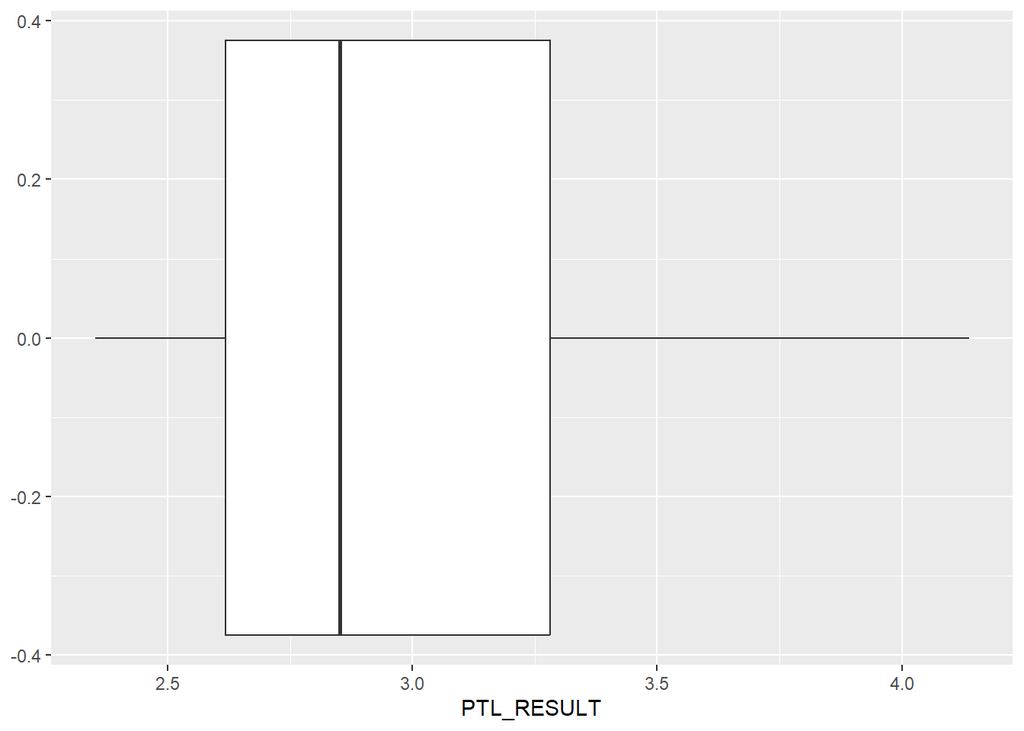

```r
phyto_rf %>%
  select(PTL_RESULT, TID_4093) %>%
  filter(TID_4093 > 0) %>%
  ggplot(aes(PTL_RESULT)) +
    geom_boxplot()
```

## Random Forest

The random forest uses bootstrapping to build a decision tree from which it creates a regression model to fit the data. The purpose of the bootstrapping is to reduce overfitting the data. So far this section only produces a negative % of variance explained. Compared to PCA this method has not shown similar levels of predictive power. Future potential in using PCA to pre-select diatom taxa to reduce noise.

```r
set.seed(710)

randomForest(PTL_RESULT~., data = phyto_rf, ntree = 1000, mtry = 3) -> rf_result

rf_result
```

```
##
## Call:
##  randomForest(formula = PTL_RESULT ~ ., data = phyto_rf, ntree = 1000,      mtry = 3)
##                Type of random forest: regression
##                      Number of trees: 1000
## No. of variables tried at each split: 3
##
##           Mean of squared residuals: 0.8942267
##                     % Var explained: -0.9
```